# Homework 3

## Data Preprocessing and Dimensionality Reduction with `scikit-learn`

### by: Yasshin Lozano

## Problem 1

Consider the Pima Indian Diabetes data set from the [UCI Machine Learning Repository](https://archive.ics.uci.edu/ml/datasets/Pima+Indians+Diabetes). The data set contains a number of biological attributes from medical reports. All patients in the dataset are females at least 21 years old of Pima Indian heritage.

The features in the dataset include:

1. Number of times pregnant
2. Plasma glucose concentration a 2 hours in an oral glucose tolerance test
3. Diastolic blood pressure (mm Hg)
4. Triceps skin fold thickness (mm)
5. 2-Hour serum insulin (mu U/ml)
6. Body mass index (weight in kg/(height in m)^2)
7. Diabetes pedigree function
8. Age (years)
9. Class variable (0 or 1)

The following chunk of code can be used to load the data

```python
import numpy as np
import pandas as pd
# url with dataset
url = "http://archive.ics.uci.edu/ml/machine-learning-databases/pima-indians-diabetes/pima-indians-diabetes.data"
dataset = pd.read_csv(url, header = None)

dataset.columns = ['Pregnancies', 'Plasma glucose', 'DPB', 'Triceps',
                   'Insulin', 'BMI', 'Pedigree function',
                   'Age', 'Class']

# print first observations
dataset.head()
```

|  | Pregnancies | Plasma glucose | DPB | Triceps | Insulin | BMI | Pedigree function | Age | Class |
| --- | --- | --- | --- | --- | --- | --- | --- | --- | --- |
| 0 | 6 | 148 | 72 | 35 | 0 | 33.6 | 0.627 | 50 | 1 |
| 1 | 1 | 85 | 66 | 29 | 0 | 26.6 | 0.351 | 31 | 0 |
| 2 | 8 | 183 | 64 | 0 | 0 | 23.3 | 0.672 | 32 | 1 |
| 3 | 1 | 89 | 66 | 23 | 94 | 28.1 | 0.167 | 21 | 0 |
| 4 | 0 | 137 | 40 | 35 | 168 | 43.1 | 2.288 | 33 | 1 |

```python
# separate the data from the target attributes
X = dataset.iloc[:, 0:8].values
y = dataset.iloc[:, 8].values
```

You can find more information [here](http://archive.ics.uci.edu/ml/machine-learning-databases/pima-indians-diabetes/pima-indians-diabetes.names)

(a) Use

`from sklearn.preprocessing import MinMaxScaler`

to rescale the attributes into the range between 0 and 1.

Print the first lines of the transformed data to confirmed the rescaling.

```python
from sklearn.preprocessing import MinMaxScaler
mms = MinMaxScaler(feature_range=(0,1))
X_norm = mms.fit_transform(X)
X_norm_df = pd.DataFrame(X_norm)
X_norm_df.columns = ['Pregnancies', 'Plasma glucose', 'DPB', 'Triceps',
                   'Insulin', 'BMI', 'Pedigree function',
                   'Age']
X_norm_df.head()
```

|  | Pregnancies | Plasma glucose | DPB | Triceps | Insulin | BMI | Pedigree function | Age |
| --- | --- | --- | --- | --- | --- | --- | --- | --- |
| 0 | 0.352941 | 0.743719 | 0.590164 | 0.353535 | 0.000000 | 0.500745 | 0.234415 | 0.483333 |
| 1 | 0.058824 | 0.427136 | 0.540984 | 0.292929 | 0.000000 | 0.396423 | 0.116567 | 0.166667 |
| 2 | 0.470588 | 0.919598 | 0.524590 | 0.000000 | 0.000000 | 0.347243 | 0.253629 | 0.183333 |
| 3 | 0.058824 | 0.447236 | 0.540984 | 0.232323 | 0.111111 | 0.418778 | 0.038002 | 0.000000 |
| 4 | 0.000000 | 0.688442 | 0.327869 | 0.353535 | 0.198582 | 0.642325 | 0.943638 | 0.200000 |

(b) Use

`from sklearn.preprocessing import StandardScaler`

to standardize the observations (with a mean of 0 and a standard deviation of 1).

```python
from sklearn.preprocessing import StandardScaler
stdsc = StandardScaler()
X_std = stdsc.fit_transform(X)
X_std_df = pd.DataFrame(X)
X_std_df.columns = ['Pregnancies', 'Plasma glucose', 'DPB', 'Triceps',
                   'Insulin', 'BMI', 'Pedigree function',
                   'Age']
X_std_df.head()
```

|  | Pregnancies | Plasma glucose | DPB | Triceps | Insulin | BMI | Pedigree function | Age |
| --- | --- | --- | --- | --- | --- | --- | --- | --- |
| 0 | 6.0 | 148.0 | 72.0 | 35.0 | 0.0 | 33.6 | 0.627 | 50.0 |
| 1 | 1.0 | 85.0 | 66.0 | 29.0 | 0.0 | 26.6 | 0.351 | 31.0 |
| 2 | 8.0 | 183.0 | 64.0 | 0.0 | 0.0 | 23.3 | 0.672 | 32.0 |
| 3 | 1.0 | 89.0 | 66.0 | 23.0 | 94.0 | 28.1 | 0.167 | 21.0 |
| 4 | 0.0 | 137.0 | 40.0 | 35.0 | 168.0 | 43.1 | 2.288 | 33.0 |

## Problem 2

A useful approach to select relevant features from a dataset is to use a random forest, an ensemble technique available in `scikit-learn`. Consider the Boston housing data set that gives housing values and other statistics in each of 506 suburbs of Boston based on a 1970 census.

The random forest implementation in `scikit-learn` already collects feature importances for us so that we can access them via the `feature_importances_` attribute after fitting a `RandomForestClassifier`.

- Find the **three most relevant features**. The chunk of code below loads the Boston housing data set

```python
import sklearn.datasets as sets
boston = sets.load_boston()

# print the data description
#print(boston.DESCR)
```

```python
# Convert boston.data into a pandas data frame.
bos = pd.DataFrame(boston.data)
```

```python
# Replace current column names, which are just numbers, with the feature names.
bos.columns = boston.feature_names
```

We can check now the first set of observations in `bos`

```python
bos.head()
```

|  | CRIM | ZN | INDUS | CHAS | NOX | RM | AGE | DIS | RAD | TAX | PTRATIO | B | LSTAT |
| --- | --- | --- | --- | --- | --- | --- | --- | --- | --- | --- | --- | --- | --- |
| 0 | 0.00632 | 18.0 | 2.31 | 0.0 | 0.538 | 6.575 | 65.2 | 4.0900 | 1.0 | 296.0 | 15.3 | 396.90 | 4.98 |
| 1 | 0.02731 | 0.0 | 7.07 | 0.0 | 0.469 | 6.421 | 78.9 | 4.9671 | 2.0 | 242.0 | 17.8 | 396.90 | 9.14 |
| 2 | 0.02729 | 0.0 | 7.07 | 0.0 | 0.469 | 7.185 | 61.1 | 4.9671 | 2.0 | 242.0 | 17.8 | 392.83 | 4.03 |
| 3 | 0.03237 | 0.0 | 2.18 | 0.0 | 0.458 | 6.998 | 45.8 | 6.0622 | 3.0 | 222.0 | 18.7 | 394.63 | 2.94 |
| 4 | 0.06905 | 0.0 | 2.18 | 0.0 | 0.458 | 7.147 | 54.2 | 6.0622 | 3.0 | 222.0 | 18.7 | 396.90 | 5.33 |

```
 1) INDUS                          0.256933
 2) AGE                            0.165897
 3) RAD                            0.137359
 4) DIS                            0.125553
 5) CHAS                           0.089227
 6) ZN                             0.083901
 7) RM                             0.072249
 8) NOX                            0.068881
```

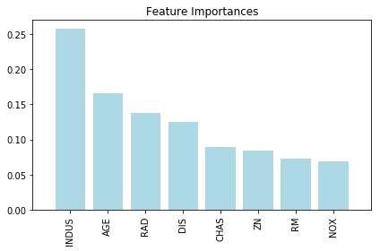

```python
#Random Forest
from sklearn.ensemble import RandomForestClassifier
import matplotlib.pyplot as plt

features = bos.columns[1:]
forest = RandomForestClassifier(n_estimators=10000,
                                random_state=0,
                                n_jobs=-1)

forest.fit(X, y)
# get feature importance
importances = forest.feature_importances_

indices = np.argsort(importances)[::-1]

# print feature importance
for f in range(X.shape[1]):
    print("%2d) %-*s %f" % (f + 1, 30,
                            features[indices[f]],
                            importances[indices[f]]))

# plot a feature importance chart
plt.title('Feature Importances')
plt.bar(range(X.shape[1]),
        importances[indices],
        color='lightblue',
        align='center')

plt.xticks(range(X.shape[1]),
           features[indices], rotation=90)
plt.xlim([-1, X.shape[1]])
plt.tight_layout()
plt.show()
```

We will assign class labels to each of the 506 Boston houses in terms of whether their prices are below the first quartile, in between the first quartile and the median, in between the median and the third quartile or above the third quartile. With such setup, the class labels will correspond to `'low'`, `'fair'`, `'high'` or `'very high'`, respectively.

Since `boston.target` contains the housing prices, we can add these target prices to the `bos` data frame as follows:

```python
bos['MEDV'] = boston.target
```

And now we create the classes based on the values of `MEDV`

```python
bos['Labels'] = np.where(
    bos['MEDV'] < np.percentile(bos['MEDV'].values, 25),'low',
    np.where(
        (bos['MEDV'] > np.percentile(bos['MEDV'].values, 25))
        &(bos['MEDV'] < np.median(bos['MEDV'].values)),'fair',
        np.where((bos['MEDV'] > np.median(bos['MEDV'].values))
                 & (bos['MEDV'] < np.percentile(bos['MEDV'].values, 75)),'high',
                 'very high')))
```

We can confirm that the labels were created as we expected, and inspect the last rows in the dataset by using the `.tail()` method

```python
bos.tail()
```

|  | CRIM | ZN | INDUS | CHAS | NOX | RM | AGE | DIS | RAD | TAX | PTRATIO | B | LSTAT | MEDV | Labels |
| --- | --- | --- | --- | --- | --- | --- | --- | --- | --- | --- | --- | --- | --- | --- | --- |
| 501 | 0.06263 | 0.0 | 11.93 | 0.0 | 0.573 | 6.593 | 69.1 | 2.4786 | 1.0 | 273.0 | 21.0 | 391.99 | 9.67 | 22.4 | high |
| 502 | 0.04527 | 0.0 | 11.93 | 0.0 | 0.573 | 6.120 | 76.7 | 2.2875 | 1.0 | 273.0 | 21.0 | 396.90 | 9.08 | 20.6 | fair |
| 503 | 0.06076 | 0.0 | 11.93 | 0.0 | 0.573 | 6.976 | 91.0 | 2.1675 | 1.0 | 273.0 | 21.0 | 396.90 | 5.64 | 23.9 | high |
| 504 | 0.10959 | 0.0 | 11.93 | 0.0 | 0.573 | 6.794 | 89.3 | 2.3889 | 1.0 | 273.0 | 21.0 | 393.45 | 6.48 | 22.0 | high |
| 505 | 0.04741 | 0.0 | 11.93 | 0.0 | 0.573 | 6.030 | 80.8 | 2.5050 | 1.0 | 273.0 | 21.0 | 396.90 | 7.88 | 11.9 | low |

- You should be able to create a plot of *feature importance* as done in class

## Problem 3

PCA (Principal Component Analysis) can also be helpful for data visualization purposes.

For instance the `iris` dataset contains four features for each observation, but we can perform PCA to create a two-dimensional plot of the data.

- Use the examples discussed in class to perform PCA (with 2 components) on the `iris` dataset, and create a visualization of this classic dataset.
- Show a plot showing the *explained variance ratio*

The code below loads the dataset from `scikit-learn`

```python
from sklearn import datasets
iris = datasets.load_iris()

X = iris.data
y = iris.target
target_names = iris.target_names
```

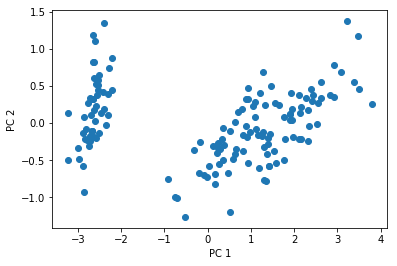

```python
from sklearn.decomposition import PCA

pca = PCA(n_components=2)
X_pca = pca.fit_transform(X)

plt.scatter(X_pca[:, 0], X_pca[:, 1])
plt.xlabel('PC 1')
plt.ylabel('PC 2')
plt.show()
```

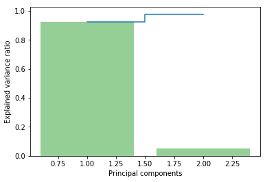

```python
pca = PCA(n_components=2)
X_pca = pca.fit_transform(X)
pca.explained_variance_ratio_

plt.bar(range(1,3), pca.explained_variance_ratio_, alpha=0.5, align='center')
plt.step(range(1, 3),np.cumsum(pca.explained_variance_ratio_), where='mid')
plt.ylabel('Explained variance ratio')
plt.xlabel('Principal components')
plt.show()
```